####This assignment makes use of data from a personal activity monitoring device. This device collects data at 5 minute intervals through out the day. The data consists of two months of data from an anonymous individual collected during the months of October and November, 2012 and include the number of steps taken in 5 minute intervals each day.

###Overview of Data

####The data for this assignment can be downloaded from the course web site:

####Dataset: (https://d396qusza40orc.cloudfront.net/repdata%2Fdata%2Factivity.zip)

####The variables included in this dataset are:

###* steps: Number of steps taking in a 5-minute interval (missing values are coded as NA) ###* date: The date on which the measurement was taken in YYYY-MM-DD format ###* interval: Identifier for the 5-minute interval in which measurement was taken

#1. Code for reading in the dataset and/or processing the data

####1. Load and Preprocess the data

```r
## Download project file to working directory -
## "https://d396qusza40orc.cloudfront.net/repdata%2Fdata%2Factivity.zip"
## Load packages to support analysis
```

```r
library(ggplot2)
library(base)
library(chron)
library(dplyr)
## set working directory & load file
setwd("C:/Users/udwii/Desktop/datasharing/Project 3")
activity <- read.csv("activity.csv", header=TRUE)
```

####2. Process/transform the data(if necessary) into a format suitable for analysis

```r
head(activity)
```

```
##   steps       date interval
## 1    NA 01-10-2012        0
## 2    NA 01-10-2012        5
## 3    NA 01-10-2012       10
## 4    NA 01-10-2012       15
## 5    NA 01-10-2012       20
## 6    NA 01-10-2012       25
```

#What is mean total number of steps taken per day? For this part of the assignment, you can ignore the missing values in the dataset. ####1. Calculate the total number of steps taken per day

```r
##Computing the number of steps
actSteps <-aggregate(steps ~ date, activity, FUN=sum)
##View the head data for number of steps
head(actSteps)
```

```
##         date steps
## 1 02-10-2012   126
## 2 02-11-2012 10600
## 3 03-10-2012 11352
## 4 03-11-2012 10571
## 5 04-10-2012 12116
## 6 05-10-2012 13294
```

#2. Histogram of the total number of steps taken each day ####2. If you do not understand the difference between a histogram and a barplot, research the difference between them. Make a histogram of the total number of steps taken each day

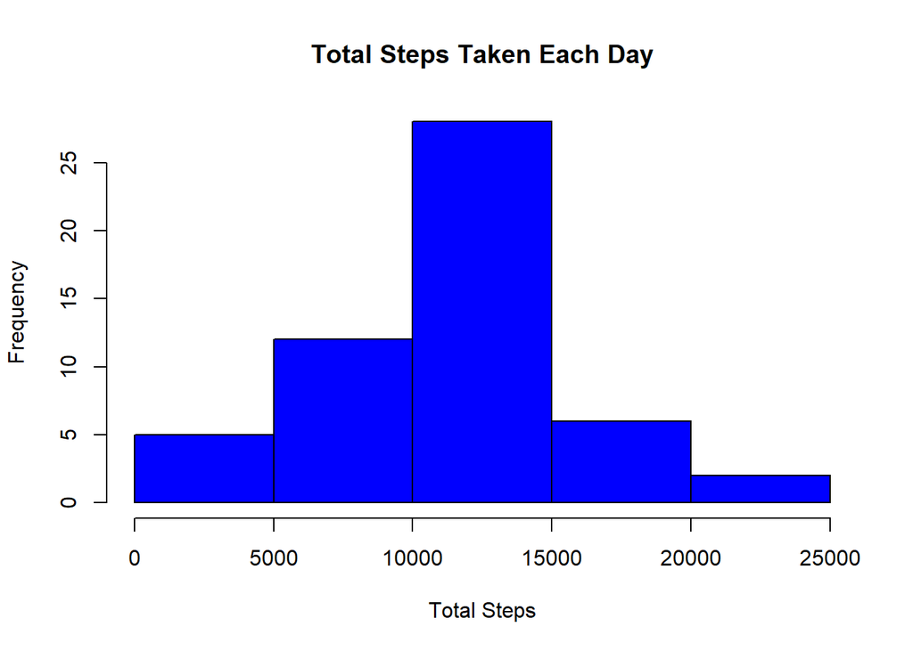

```r
##plot a histogram using base plotting
hist(actSteps$steps, col="blue",
                     xlab = "Total Steps",
                     ylab = "Frequency",
                     main = "Total Steps Taken Each Day")
```

#3. Mean and median number of steps taken each day ####3. Calculate and report the mean and median of the total number of steps taken per day

```r
## Calculate the mean
actMean <- mean(actSteps$steps)
##Mean for the number of steps taken per day
actMean
```

```
## [1] 10766.19
```

```r
## Calculate the median
actMedian <- median(actSteps$steps)
##Median for the number of steps taken per day
actMedian
```

```
## [1] 10765
```

###The MEAN is 10766.19 and the MEDIAN is 10765

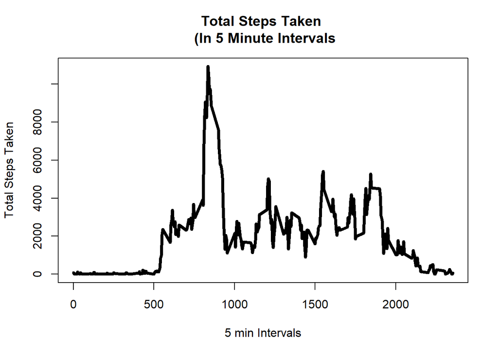

```r
##Aggregating the number of steps over a 5-minute time interval
intAggr <- aggregate(steps ~ interval, activity, FUN=sum)
##Applying base plotting to build a line graph
plot(intAggr$interval, intAggr$steps,
                        type = "l",
                        lwd = 4, xlab="5 min Intervals",
                        ylab="Total Steps Taken",
                        main="Total Steps Taken \n (In 5 Minute Intervals")
```

#5. The 5-minute interval that, on average, contains the maximum number of steps ####2. Which 5-minute interval, on average across all the days in the dataset, contains the maximum number of steps?

```r
##Identify the 5-minute interval that contains the maximum number of steps
filter(intAggr, steps==max(steps))
```

```
##   interval steps
## 1      835 10927
```

### The 5-minute interval that contains the maximum number of steps is 835, with a maximum number of steps equal to 10927

#6. Code to describe and show a strategy for imputing missing data ##Imputing missing values ###Note there are a number of days/intervals where there are missing values (coded as NA). The presence of missing days may introduce bias into some calculations or summaries of the data.

####1. Calculate and report the total number of missing values in the dataset (i.e., the total number of rows with NAs)

```r
## Identify the total number of "NA" values in the dataset
sum(is.na(activity$steps))
```

```
## [1] 2304
```